# Session 3 extension: cumulative link mixed models

Ordinal responses with grouped observations

O Rodriguez de Rivera Ortega, PhD

University of Exeter

# 1 Session overview

## 1.1 What is this session about?

This optional extension introduces **cumulative link mixed models**, often abbreviated to **CLMMs**.

CLMMs are useful when the response variable is **ordinal** and observations are **grouped** or **repeated**.

An ordinal response is categorical, but the categories have a natural order. For example:

- low, medium, high;
- strongly disagree, disagree, neutral, agree, strongly agree;
- damage class 1 to 5;
- severity class none, mild, moderate, severe;
- rating from 1 = low to 5 = high.

The key point is that ordinal responses are not truly continuous. A rating of 4 is higher than a rating of 3, but the difference between 3 and 4 may not be the same as the difference between 1 and 2.

In this session, we use the `wine` dataset from the `ordinal` package. The response is a bitterness rating from 1 to 5.

The main question is:

> Do temperature and contact affect the perceived bitterness rating of wine, while accounting for differences among judges?

## 1.2 Learning outcomes

By the end of this extension, students should be able to:

- recognise ordinal responses;
- explain why ordinal responses should not always be treated as continuous;
- understand cumulative probabilities;
- understand thresholds or cut-points;
- fit a cumulative link model using `ordinal::clm()`;
- add random effects using `ordinal::clmm()`;
- interpret fixed effects in terms of higher or lower ratings;
- explain why random effects are useful for repeated ratings or grouped observations;
- produce and interpret predicted probabilities.

# 2 CLMM in context

## 2.1 Continuity from GLMMs

The GLMM session introduced models for grouped responses such as:

- binary outcomes;
- grouped binomial outcomes;
- count outcomes.

For example, we used:

```r
lme4::glmer(
  presence ~ habitat + (1 | site),
  family = binomial,
  data = my_data
)

lme4::glmer(
  count ~ treatment + (1 | site),
  family = poisson,
  data = my_data
)
```

These models combine:

- a response distribution;
- a link function;
- fixed effects;
- random effects.

A cumulative link mixed model follows the same general idea, but the response is ordinal rather than binary, count or continuous.

## 2.2 Why not use a normal linear model?

Suppose the response is a rating from 1 to 5.

A simple linear model would treat the response as continuous. This assumes that:

- ratings are equally spaced;
- predictions can take values such as 2.37 or 4.82;
- residuals are approximately normally distributed.

Sometimes this may be a reasonable approximation, especially with many categories. However, for a small number of ordered categories, an ordinal model is usually more appropriate.

A cumulative link model respects the fact that the response consists of ordered categories.

# 3 Ordinal responses

## 3.1 What makes a response ordinal?

An ordinal response has categories with a natural order.

For example:

| Rating | Meaning |
| --- | --- |
| 1 | Very low |
| 2 | Low |
| 3 | Medium |
| 4 | High |
| 5 | Very high |

The order matters, but the distances between categories are not necessarily equal.

This is different from:

- **nominal data**, where categories have no natural order, such as red, blue, green;
- **continuous data**, where numeric distances are meaningful, such as height or body mass;
- **binary data**, where there are only two outcomes, such as present or absent.

## 3.2 The idea of cumulative probabilities

Cumulative link models work with cumulative probabilities.

For a 1 to 5 rating, we can ask questions such as:

- What is the probability that the rating is 1 or below?
- What is the probability that the rating is 2 or below?
- What is the probability that the rating is 3 or below?
- What is the probability that the rating is 4 or below?

For five response categories, we need four thresholds.

## 3.3 Thresholds

Thresholds are cut-points between neighbouring response categories.

For a five-category response, the thresholds separate:

- category 1 from categories 2, 3, 4 and 5;
- categories 1 and 2 from categories 3, 4 and 5;
- categories 1, 2 and 3 from categories 4 and 5;
- categories 1, 2, 3 and 4 from category 5.

The model estimates these thresholds, together with the effects of explanatory variables.

# 4 Setup

## 4.1 Packages

```r
install.packages(c("tidyverse", "ordinal"))
```

```r
library(tidyverse)
library(ordinal)

theme_set(theme_minimal(base_size = 12))
```

# 5 Load the data

## 5.1 Wine tasting data

```r
data("wine", package = "ordinal")

wine <- wine %>%
  dplyr::mutate(
    rating = ordered(rating),
    temp = factor(temp),
    contact = factor(contact),
    judge = factor(judge),
    bottle = factor(bottle)
  )

dplyr::glimpse(wine)
```

```
## Rows: 72
## Columns: 6
## $ response <dbl> 36, 48, 47, 67, 77, 60, 83, 90, 17, 22, 14, 50, 30, 51, 90, 7…
## $ rating   <ord> 2, 3, 3, 4, 4, 4, 5, 5, 1, 2, 1, 3, 2, 3, 5, 4, 2, 3, 3, 2, 5…
## $ temp     <fct> cold, cold, cold, cold, warm, warm, warm, warm, cold, cold, c…
## $ contact  <fct> no, no, yes, yes, no, no, yes, yes, no, no, yes, yes, no, no,…
## $ bottle   <fct> 1, 2, 3, 4, 5, 6, 7, 8, 1, 2, 3, 4, 5, 6, 7, 8, 1, 2, 3, 4, 5…
## $ judge    <fct> 1, 1, 1, 1, 1, 1, 1, 1, 2, 2, 2, 2, 2, 2, 2, 2, 3, 3, 3, 3, 3…
```

The response variable is `rating`, which records bitterness on an ordered scale from 1 to 5.

The explanatory variables include:

- `temp`: wine temperature;
- `contact`: whether the wine had contact treatment;
- `judge`: the judge who rated the wine;
- `bottle`: bottle identity.

The same judges rate multiple wines, so ratings from the same judge may be more similar than ratings from different judges. This motivates using a random effect for judge.

# 6 Explore the ordinal response

## 6.1 Rating distribution

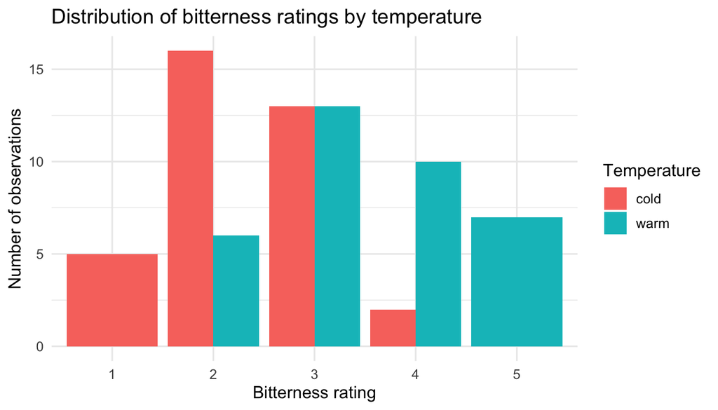

```r
ggplot(wine, aes(x = rating, fill = temp)) +
  geom_bar(position = "dodge") +
  labs(
    title = "Distribution of bitterness ratings by temperature",
    x = "Bitterness rating",
    y = "Number of observations",
    fill = "Temperature"
  )
```

This plot shows how ratings are distributed across the ordered categories.

A useful question to ask is:

> Do some treatments seem to produce more high ratings than others?

## 6.2 Ratings by temperature and contact

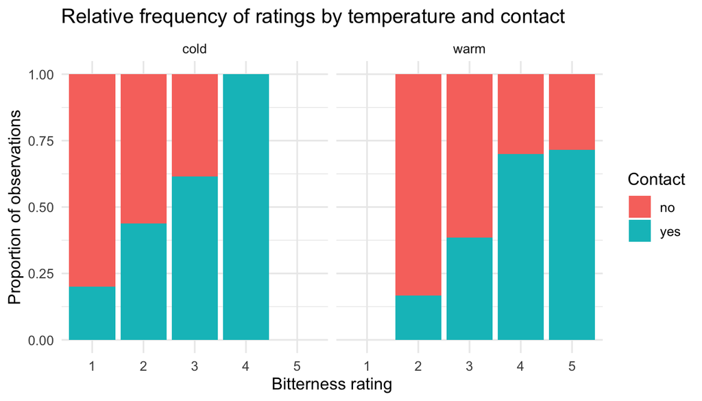

```r
ggplot(wine, aes(x = rating, fill = contact)) +
  geom_bar(position = "fill") +
  facet_wrap(~ temp) +
  labs(
    title = "Relative frequency of ratings by temperature and contact",
    x = "Bitterness rating",
    y = "Proportion of observations",
    fill = "Contact"
  )
```

Using `position = "fill"` makes each bar sum to 1. This helps compare the distribution of ratings across treatment combinations.

If one treatment combination has more observations in ratings 4 and 5, that suggests a shift towards higher bitterness.

## 6.3 Ratings by judge

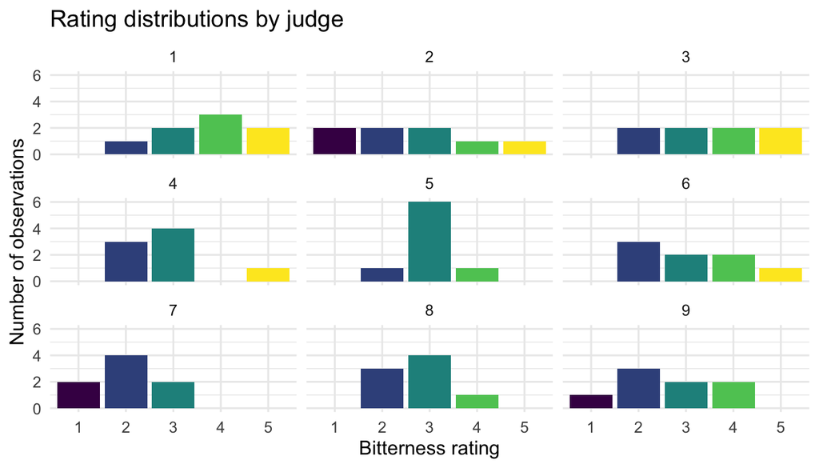

```r
ggplot(wine, aes(x = rating, fill = rating)) +
  geom_bar() +
  facet_wrap(~ judge) +
  guides(fill = "none") +
  labs(
    title = "Rating distributions by judge",
    x = "Bitterness rating",
    y = "Number of observations"
  )
```

Some judges may tend to give higher or lower ratings. A random effect for judge allows the model to account for this variation.

# 7 Cumulative link model

## 7.1 Fit a cumulative link model

We first fit a cumulative link model without random effects.

```r
clm_fit <- ordinal::clm(
  rating ~ temp * contact,
  data = wine,
  link = "logit"
)

summary(clm_fit)
```

```
## formula: rating ~ temp * contact
## data:    wine
##
##  link  threshold nobs logLik AIC    niter max.grad cond.H
##  logit flexible  72   -86.42 186.83 6(0)  5.22e-12 5.1e+01
##
## Coefficients:
##                     Estimate Std. Error z value Pr(>|z|)
## tempwarm              2.3212     0.7009   3.311 0.000928 ***
## contactyes            1.3475     0.6604   2.041 0.041300 *
## tempwarm:contactyes   0.3595     0.9238   0.389 0.697129
## ---
## Signif. codes:  0 '***' 0.001 '**' 0.01 '*' 0.05 '.' 0.1 ' ' 1
##
## Threshold coefficients:
##     Estimate Std. Error z value
## 1|2  -1.4113     0.5454  -2.588
## 2|3   1.1436     0.5097   2.244
## 3|4   3.3771     0.6382   5.292
## 4|5   4.9420     0.7509   6.581
```

This model asks whether temperature, contact and their interaction affect the ordinal bitterness rating.

The response is not treated as continuous. Instead, the model estimates probabilities for each rating category.

## 7.2 Interpreting the model output

The model output has two important sections:

1. **Threshold coefficients**
2. **Location coefficients**

The threshold coefficients define the cut-points between response categories.

The location coefficients describe how predictors shift the response towards lower or higher categories.

In the usual cumulative logit formulation used here, positive effects tend to shift probability towards higher response categories, while negative effects tend to shift probability towards lower categories.

For teaching, it is usually easiest to interpret the model using predicted probabilities rather than the raw coefficients.

# 8 Add random effects

## 8.1 Why add random judge effects?

The same judges rated multiple wines. Some judges may generally give higher ratings, while others may give lower ratings.

If we ignore this grouping, we may treat repeated ratings from the same judge as independent. That can underestimate uncertainty.

A cumulative link mixed model adds a random effect for judge:

```r
clmm_fit <- ordinal::clmm(
  rating ~ temp * contact + (1 | judge),
  data = wine,
  link = "logit",
  Hess = TRUE
)

summary(clmm_fit)
```

```
## Cumulative Link Mixed Model fitted with the Laplace approximation
##
## formula: rating ~ temp * contact + (1 | judge)
## data:    wine
##
##  link  threshold nobs logLik AIC    niter     max.grad cond.H
##  logit flexible  72   -81.54 179.07 363(1092) 2.87e-06 3.9e+01
##
## Random effects:
##  Groups Name        Variance Std.Dev.
##  judge  (Intercept) 1.276    1.13
## Number of groups:  judge 9
##
## Coefficients:
##                     Estimate Std. Error z value Pr(>|z|)
## tempwarm              2.9467     0.7611   3.872 0.000108 ***
## contactyes            1.7174     0.7020   2.447 0.014421 *
## tempwarm:contactyes   0.2315     0.9540   0.243 0.808233
## ---
## Signif. codes:  0 '***' 0.001 '**' 0.01 '*' 0.05 '.' 0.1 ' ' 1
##
## Threshold coefficients:
##     Estimate Std. Error z value
## 1|2  -1.6627     0.7003  -2.374
## 2|3   1.4439     0.6642   2.174
## 3|4   4.1687     0.8438   4.940
## 4|5   6.0440     0.9898   6.106
```

The term `(1 | judge)` allows each judge to have their own baseline tendency to give higher or lower ratings.

This is similar to random-intercept GLMMs, but the response is ordinal.

## 8.2 Compare CLM and CLMM

```r
AIC(clm_fit, clmm_fit)
```

```
##          df      AIC
## clm_fit   7 186.8324
## clmm_fit  8 179.0719
```

A lower AIC indicates a better trade-off between model fit and complexity.

If the CLMM has lower AIC, this suggests that accounting for judge-level variation improves the model.

## 8.3 Random judge variation

```r
judge_effects <- ranef(clmm_fit)$judge %>%
  as.data.frame() %>%
  tibble::rownames_to_column("judge") %>%
  dplyr::rename(random_intercept = `(Intercept)`)

judge_effects
```

```
##   judge random_intercept
## 1     1       1.70281552
## 2     2      -0.56590603
## 3     3       0.95619529
## 4     4      -0.05737537
## 5     5       0.23060746
## 6     6       0.47298042
## 7     7      -1.90404021
## 8     8      -0.27369484
## 9     9      -0.55562230
```

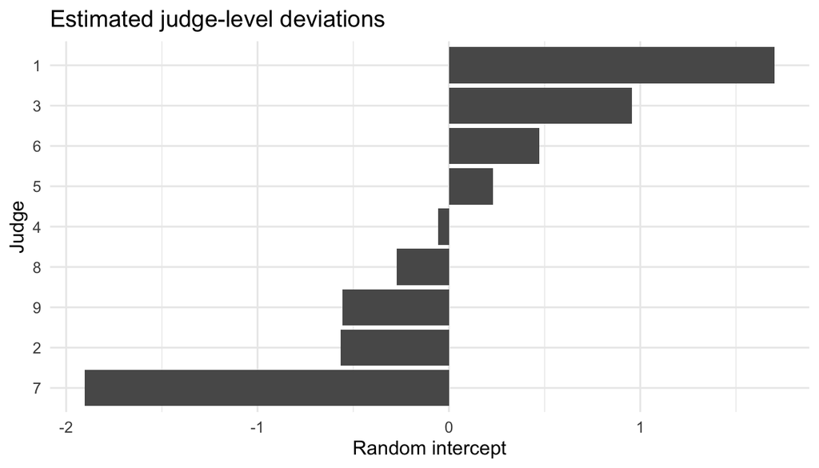

```r
ggplot(judge_effects, aes(x = reorder(judge, random_intercept), y = random_intercept)) +
  geom_col() +
  coord_flip() +
  labs(
    title = "Estimated judge-level deviations",
    x = "Judge",
    y = "Random intercept"
  )
```

Judges with positive random intercepts tend to give higher ratings than the average judge, after accounting for temperature and contact. Judges with negative random intercepts tend to give lower ratings.

# 9 Predicted probabilities

## 9.1 Prediction grid

Predicted probabilities are often the clearest way to interpret an ordinal model.

Here we use the simpler cumulative link model for prediction, because it gives clean population-level predicted probabilities for each temperature and contact combination.

```r
new_wine <- tidyr::expand_grid(
  temp = levels(wine$temp),
  contact = levels(wine$contact)
)

new_wine
```

```
## # A tibble: 4 × 2
##   temp  contact
##   <chr> <chr>
## 1 cold  no
## 2 cold  yes
## 3 warm  no
## 4 warm  yes
```

## 9.2 Obtain predicted probabilities

```r
prob_matrix <- predict(
  clm_fit,
  newdata = new_wine,
  type = "prob"
)$fit

pred_probs <- prob_matrix %>%
  as.data.frame() %>%
  tibble::as_tibble() %>%
  rlang::set_names(paste0("rating_", levels(wine$rating))) %>%
  dplyr::bind_cols(new_wine, .) %>%
  tidyr::pivot_longer(
    cols = dplyr::starts_with("rating_"),
    names_to = "rating",
    names_prefix = "rating_",
    values_to = "probability"
  ) %>%
  dplyr::mutate(
    rating = factor(
      rating,
      levels = levels(wine$rating),
      ordered = TRUE
    )
  )

pred_probs
```

```
## # A tibble: 20 × 4
##    temp  contact rating probability
##    <chr> <chr>   <ord>        <dbl>
##  1 cold  no      1          0.196
##  2 cold  no      2          0.562
##  3 cold  no      3          0.209
##  4 cold  no      4          0.0259
##  5 cold  no      5          0.00709
##  6 cold  yes     1          0.0596
##  7 cold  yes     2          0.390
##  8 cold  yes     3          0.435
##  9 cold  yes     4          0.0894
## 10 cold  yes     5          0.0267
## 11 warm  no      1          0.0234
## 12 warm  no      2          0.212
## 13 warm  no      3          0.506
## 14 warm  no      4          0.190
## 15 warm  no      5          0.0678
## 16 warm  yes     1          0.00432
## 17 warm  yes     2          0.0486
## 18 warm  yes     3          0.290
## 19 warm  yes     4          0.371
## 20 warm  yes     5          0.286
```

This table gives the predicted probability of each rating category for each combination of temperature and contact.

## 9.3 Plot predicted probabilities

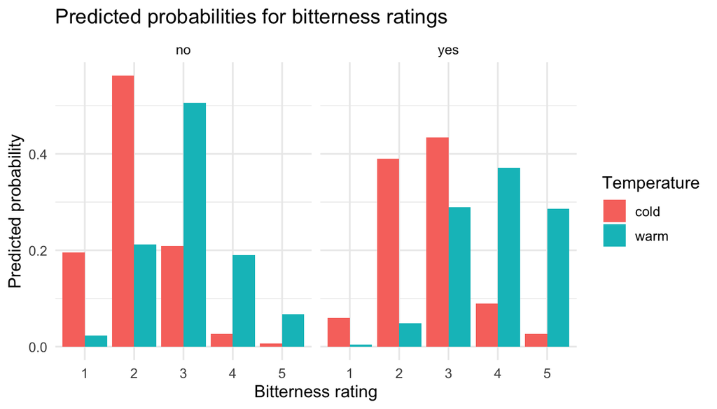

```r
ggplot(pred_probs, aes(x = rating, y = probability, fill = temp)) +
  geom_col(position = "dodge") +
  facet_wrap(~ contact) +
  labs(
    title = "Predicted probabilities for bitterness ratings",
    x = "Bitterness rating",
    y = "Predicted probability",
    fill = "Temperature"
  )
```

This plot is usually easier to interpret than the coefficient table.

For example, we can ask:

- Which treatment combination has the largest probability of high bitterness ratings?
- Which treatment combination has the largest probability of low bitterness ratings?
- Does temperature change the full distribution of ratings, rather than only the mean?

# 10 Interpretation

## 10.1 Interpreting treatment effects

In an ordinal model, predictors affect the probability distribution across ordered categories.

A treatment may not simply increase or decrease an average. Instead, it can shift probability away from lower categories and towards higher categories.

For example, if warm temperature increases bitterness, we may see:

- lower probability of ratings 1 and 2;
- higher probability of ratings 4 and 5.

This is a more appropriate interpretation than saying that the mean rating increased by a certain amount.

## 10.2 Interpreting random effects

The random judge effect captures systematic differences among judges.

Some judges may be stricter and give lower ratings. Other judges may be more likely to give high bitterness ratings.

The random effect does not mean that judge is the main scientific interest. Instead, it accounts for repeated ratings and judge-to-judge variation.

# 11 Practical exercise

## 11.1 Exercise: extend the model

1. Fit a model with `temp + contact` but no interaction.
2. Compare it with the interaction model.
3. Add a random effect for `bottle`.
4. Which model would you prefer and why?
5. Plot predicted probabilities for your preferred fixed-effect model.

```r
clm_additive <- ordinal::clm(
  rating ~ temp + contact,
  data = wine,
  link = "logit"
)

clm_interaction <- ordinal::clm(
  rating ~ temp * contact,
  data = wine,
  link = "logit"
)

AIC(clm_additive, clm_interaction)

clmm_judge_bottle <- ordinal::clmm(
  rating ~ temp * contact + (1 | judge) + (1 | bottle),
  data = wine,
  link = "logit",
  Hess = TRUE
)
```

# 12 Exercise solution

## 12.1 1. Fit an additive model

This model assumes that temperature and contact have separate additive effects on the ordinal rating.

## 12.2 2. Compare additive and interaction models

The interaction model allows the effect of temperature to depend on contact, and the effect of contact to depend on temperature.

If the interaction model has much lower AIC, it may be preferred. If the AIC values are similar, the additive model may be preferred because it is simpler.

## 12.3 3. Add random effects for judge and bottle

The model with both judge and bottle random effects allows for:

- differences among judges;
- differences among bottles.

This may be useful if some bottles tend to receive higher or lower ratings, beyond the effects of temperature and contact.

## 12.4 4. Which model would you prefer?

```r
#I would compare models using AIC, but I would also consider the study design. Because the same judges rated multiple wines, a random effect for judge is important. A random effect for bottle may also be useful if ratings are clustered by bottle. If the bottle random effect does not improve AIC or causes instability, I would keep the simpler judge random-effect model.
```

# 13 Summary

In this session, we introduced cumulative link mixed models for ordinal responses.

Key points:

- Ordinal responses have ordered categories.
- The distances between categories are not necessarily equal.
- Cumulative link models use cumulative probabilities and thresholds.
- Fixed effects shift probability towards lower or higher response categories.
- Random effects account for grouped or repeated ordinal observations.
- Predicted probabilities are often the clearest way to interpret the model.
- CLMMs extend the GLMM idea to ordinal responses.

# 14 Transition

| Response type | Example | Possible model |
| --- | --- | --- |
| Continuous | Body mass | Linear model or LMM |
| Binary | Present/absent | Logistic GLM or GLMM |
| Count | Number of individuals | Poisson or negative-binomial GLM/GLMM |
| Ordinal | Rating 1 to 5 | Cumulative link model or CLMM |

The main message is:

> Always start by asking what kind of response variable you have.